# AFDMD-111 Estadística

Lectura de archivos en R

Armando Patricio Piña Canul

20/09/2023

# Lectura de archivos en R

`R` puede leer una gran cantidad de archivos incluyendo archivos `.txt`, `.csv`, `.xls`, `.pdf`, etc. Mediante el uso del paquete `tabulizer` se pueden leer tablas que se encuentran en documentos `PDF`. En la siguiente actividad se instalará y cargará el paquete `tabulizer` mediante los comandos:

```r
install.packages("tabulizer", dependencies = TRUE)   # Instala tabulizer
library(tabulizer)                                   # Carga tabulizer
```

Posteriormente se leerá la tabla localizada en el archivo `seccion_calificacionesmsosa247.pdf` que se encuentra en la sección de **archivos** del *Teams* (lo anterior se puede hacer mediante el comando `extract_tables` del tabulizer). Una vez cargada la tabla que se llamará `tablaAlumnos` se realizarán las siguientes actividades:

#### Extrayendo datos

```r
pdf_path <- "F:/ESTADISTICA/TAREAS FINALIZADAS/TAREA 3 - 20_SEP - lectura de archivos/seccion_calificacionesmsosa247.pdf" # Aqui se pone la ubicación del archivo
resultados <- extract_tables(pdf_path)
tablaAlumnos <- as.data.frame(resultados[[1]])
print(tablaAlumnos)
```

```
   V1        V2                              V3      V4      V5  V6     V7
1  No Matricula                          Nombre Parcial Parcial Ev. Calif.
2   1 150300135       ALEJO ALEJANDRO / MIJARES       8       7   7      7
3   2 150300161       CAN BACAB / HECTOR ARTURO      10       8   8      9
4   3 150300087      CAN BACAB / SERGIO ANTONIO       7       8   9      8
5   4 140300086 CERVANTES VILLEGAS / ALAN JAIME       0       0   0      0
6   5 150300109    CONSTANTINO ISNEROS / MOISES       9       9   6      8
7   6 150300170          CORONA MERCADO / JESUS       7       6   5      6
8   7 150300508  DE LA CRUZ MARTÍNEZ / MAURICIO       8       3  10      7
9   8 150300107  GALINDO ARROYO / FERNANDO IVAN       7       9   6      7
10  9 150300511         GARCIA VAZQUEZ / BRANDO       8       8   8      8
 [ reached 'max' / getOption("max.print") -- omitted 15 rows ]
```

# Ejercicios PDF

1.- Graficar `No` contra `Parcial 1`.

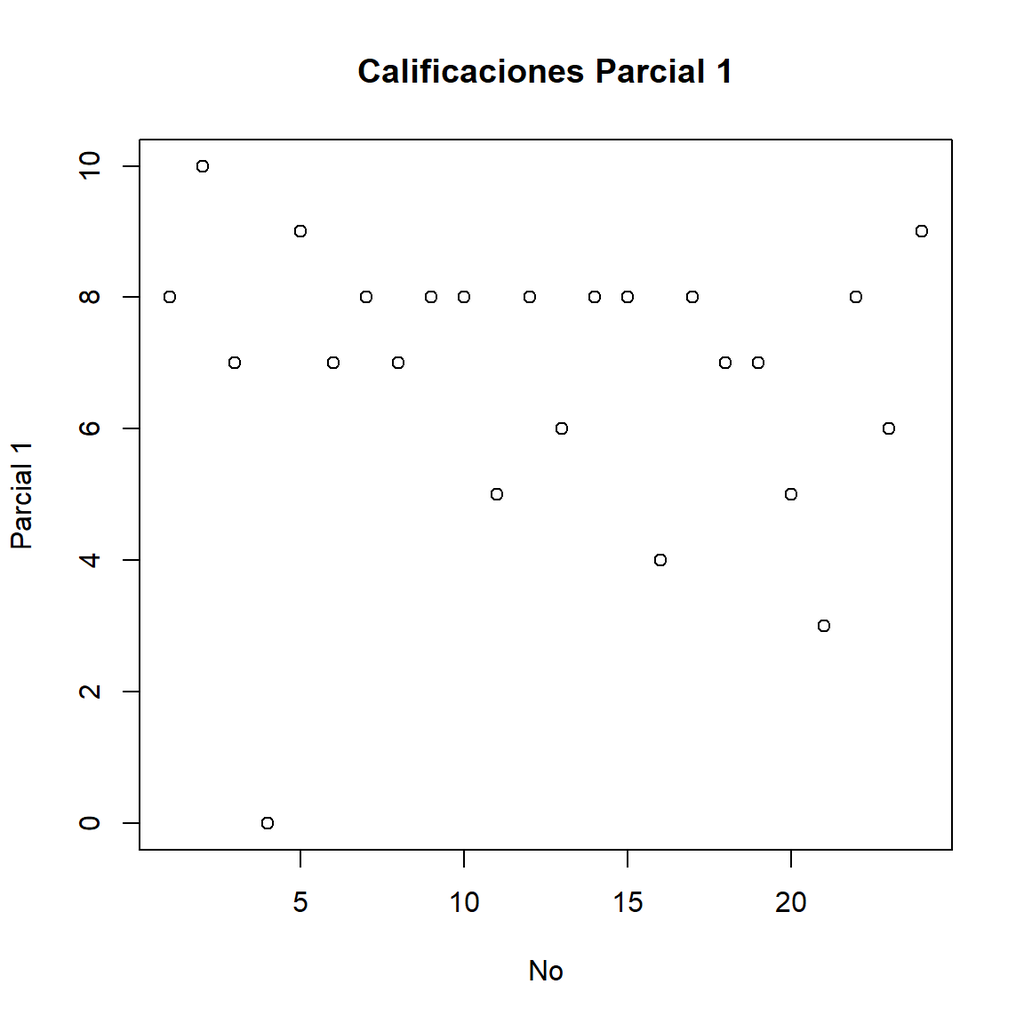

```r
datos <- tablaAlumnos
plot(datos$V1, datos$V4, main = "Calificaciones Parcial 1", xlab = "No", ylab = "Parcial 1")
```

2.- Graficar `No` contra `Parcial 2`.

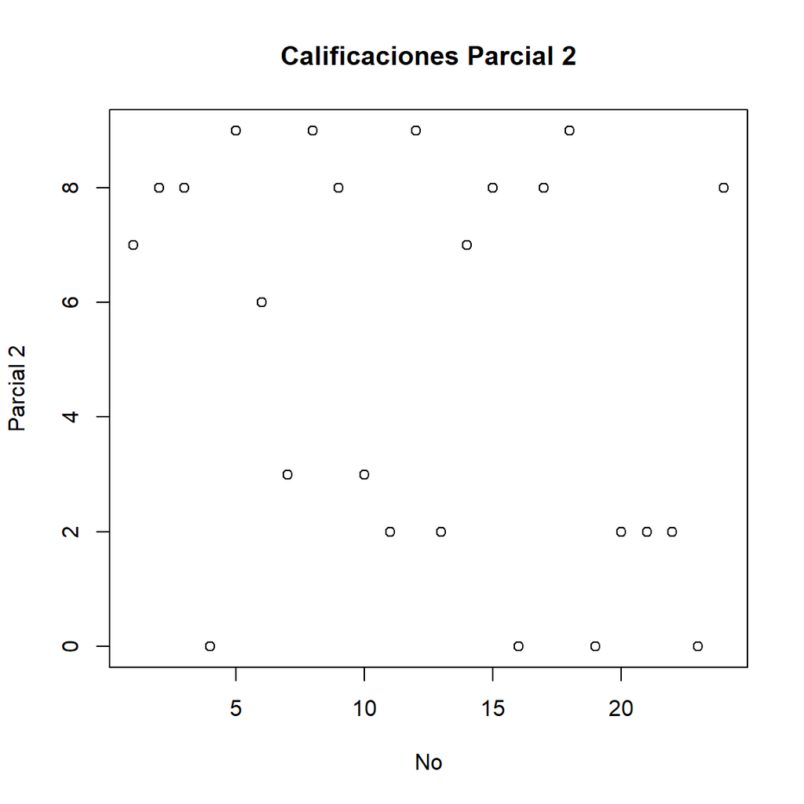

```r
datos <- tablaAlumnos
plot(datos$V1, datos$V5, main = "Calificaciones Parcial 2", xlab = "No", ylab = "Parcial 2")
```

3.- Renombrar `Ev.` a `Parcial 3` (mostrar el `data.frame` resultante).

```r
Parcial3 <- "Parcial3"
Parcial1 <- "Parcial1"
Parcial2 <- "Parcial2"
tablaAlumnos[1, 6] <- Parcial3
tablaAlumnos[1, 4] <- Parcial1
tablaAlumnos[1, 5] <- Parcial2
print(tablaAlumnos)
```

```
   V1        V2                              V3       V4       V5       V6
1  No Matricula                          Nombre Parcial1 Parcial2 Parcial3
2   1 150300135       ALEJO ALEJANDRO / MIJARES        8        7        7
3   2 150300161       CAN BACAB / HECTOR ARTURO       10        8        8
4   3 150300087      CAN BACAB / SERGIO ANTONIO        7        8        9
5   4 140300086 CERVANTES VILLEGAS / ALAN JAIME        0        0        0
6   5 150300109    CONSTANTINO ISNEROS / MOISES        9        9        6
7   6 150300170          CORONA MERCADO / JESUS        7        6        5
8   7 150300508  DE LA CRUZ MARTÍNEZ / MAURICIO        8        3       10
9   8 150300107  GALINDO ARROYO / FERNANDO IVAN        7        9        6
10  9 150300511         GARCIA VAZQUEZ / BRANDO        8        8        8
       V7
1  Calif.
2       7
3       9
4       8
5       0
6       8
7       6
8       7
9       7
10      8
 [ reached 'max' / getOption("max.print") -- omitted 15 rows ]
```

4.- Graficar `No` contra `Parcial 1`, `Parcial 2`.

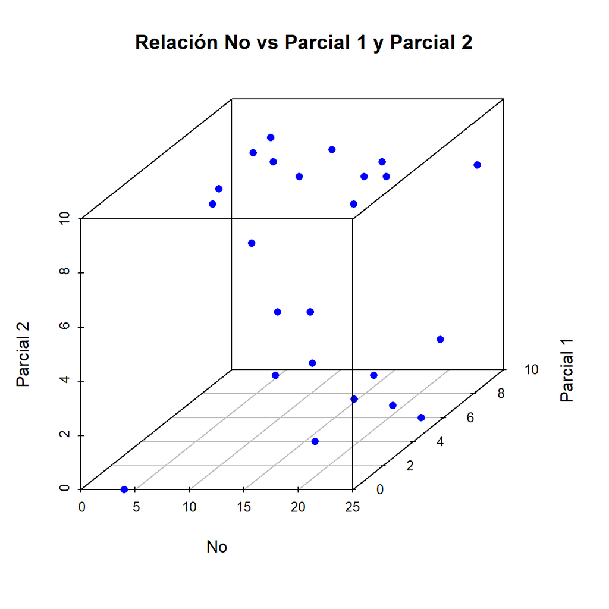

```r
library(scatterplot3d)
scatterplot3d(tablaAlumnos$V1, tablaAlumnos$V4, tablaAlumnos$V5,
              main = "Relación No vs Parcial 1 y Parcial 2",
              xlab = "No", ylab = "Parcial 1", zlab = "Parcial 2",
              color = "blue", pch = 16)
```

5.- ¿Cuál es la media de las calificaciones finales? ¿Quién obtuvo la calificación más baja? ¿Quién obtuvo el mejor promedio? (anexar el código que lo calcula).

```r
#Tuve que renombrar las columnas
nuevos_nombres <- tablaAlumnos[1, , drop = TRUE]
colnames(tablaAlumnos) <- nuevos_nombres
tablaAlumnos <- tablaAlumnos[-1, ]

#Calificación más baja
calfmedia <- mean(tablaAlumnos$Calif., na.rm = TRUE)
calfbaja <- min(tablaAlumnos$Calif.)
calfmejor <- max(tablaAlumnos$Calif.)

#Imprimir resultados
print(paste("Media Calificacion:", calfmedia))
```

```
[1] "Media Calificacion: NA"
```

```r
print(paste("Calificación más baja:", calfbaja))
```

```
[1] "Calificación más baja: 0"
```

```r
print(paste("La mejor Calificiación:", calfmejor))
```

```
[1] "La mejor Calificiación: 9"
```

6.- Cree una nueva columna llamada `promedio` (esto lo puede hacer con `mutate` del paquete `dplyr`) y compárela con la columna `Calif.` (¿Qué se puede observar?).

```r
tablaAlumnos$Calif. <- as.numeric(tablaAlumnos$Calif.)
valores_no_numericos <- tablaAlumnos$Calif.[!is.na(tablaAlumnos$Calif.) & !is.numeric(tablaAlumnos$Calif.)]
if (length(valores_no_numericos) > 0) {
  print(paste("Valores no numéricos encontrados en 'Calif.':", toString(valores_no_numericos)))
} else {
  tablaAlumnos <- tablaAlumnos %>%
    mutate(promedio = 2 * Calif.)
  print(head(tablaAlumnos))
}
```

```
  No Matricula                          Nombre Parcial1 Parcial2 Parcial3
2  1 150300135       ALEJO ALEJANDRO / MIJARES        8        7        7
3  2 150300161       CAN BACAB / HECTOR ARTURO       10        8        8
4  3 150300087      CAN BACAB / SERGIO ANTONIO        7        8        9
5  4 140300086 CERVANTES VILLEGAS / ALAN JAIME        0        0        0
6  5 150300109    CONSTANTINO ISNEROS / MOISES        9        9        6
7  6 150300170          CORONA MERCADO / JESUS        7        6        5
  Calif. promedio
2      7       14
3      9       18
4      8       16
5      0        0
6      8       16
7      6       12
```

Se observa la suma de los valores

# Ejercicios CSV

Posteriormente lea el archivo `it0103_2016_01.csv` (lo puede hacer mediante el comando `read.csv()`) el cual es una versión `sucia` del archivo anterior y replique cada uno de los puntos de arriba (sí es necesario modifique el data.frame resultante).

```r
csv_path <- "F:/ESTADISTICA/TAREAS FINALIZADAS/TAREA 3 - 20_SEP - lectura de archivos/it0103_2016_01.csv"
resultados_csv <- read.csv(csv_path)
print(resultados_csv)
```

```
   No Matricula                              Nombre Calif.   Examen
1   1 150300135          ALEJO ALEJANDRO / MIJARES       7 Parcial1
2   2 150300161          CAN BACAB / HECTOR ARTURO       9 Parcial1
3   3 150300087         CAN BACAB / SERGIO ANTONIO       8 Parcial1
4   4 140300086    CERVANTES VILLEGAS / ALAN JAIME       0 Parcial1
5   5 150300109       CONSTANTINO ISNEROS / MOISES       8 Parcial1
6   6 150300170             CORONA MERCADO / JESUS       6 Parcial1
7   7 150300508     DE LA CRUZ MARTÍNEZ / MAURICIO       7 Parcial1
8   8 150300107     GALINDO ARROYO / FERNANDO IVAN       7 Parcial1
9   9 150300511            GARCIA VAZQUEZ / BRANDO       8 Parcial1
10 10 150300123               GIL GUZMAN / GIOVANY       7 Parcial1
11 11 150300093     HERNANDEZ GUZMAN / JULIO CESAR       4 Parcial1
12 12 150300092 HERNÁNDEZ VALENCIA / ESTEBAN RAMÓN       9 Parcial1
   Calificacion
1             8
2            10
3             7
4             0
5             9
6             7
7             8
8             7
9             8
10            8
11            5
12            8
 [ reached 'max' / getOption("max.print") -- omitted 60 rows ]
```

1.- Graficar `No` contra `Calif.`.

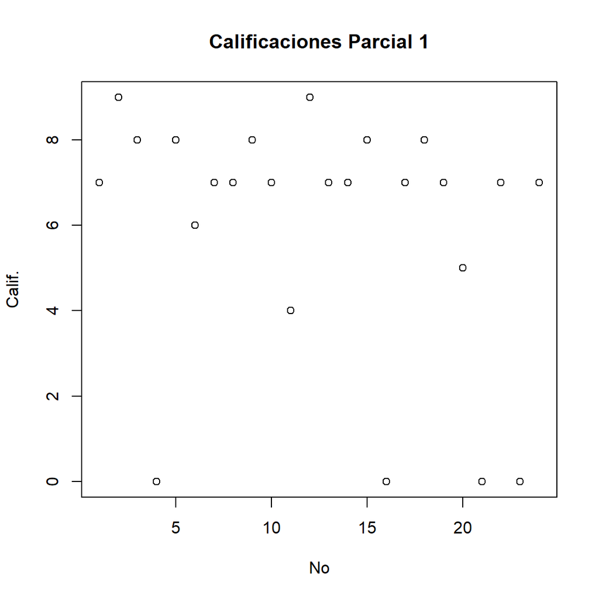

```r
datoscsv <- resultados_csv
plot(datoscsv$No, datoscsv$Calif., main = "Calificaciones Parcial 1", xlab = "No", ylab = "Calif.")
```

2.- Graficar `No` contra `Calificacion`.

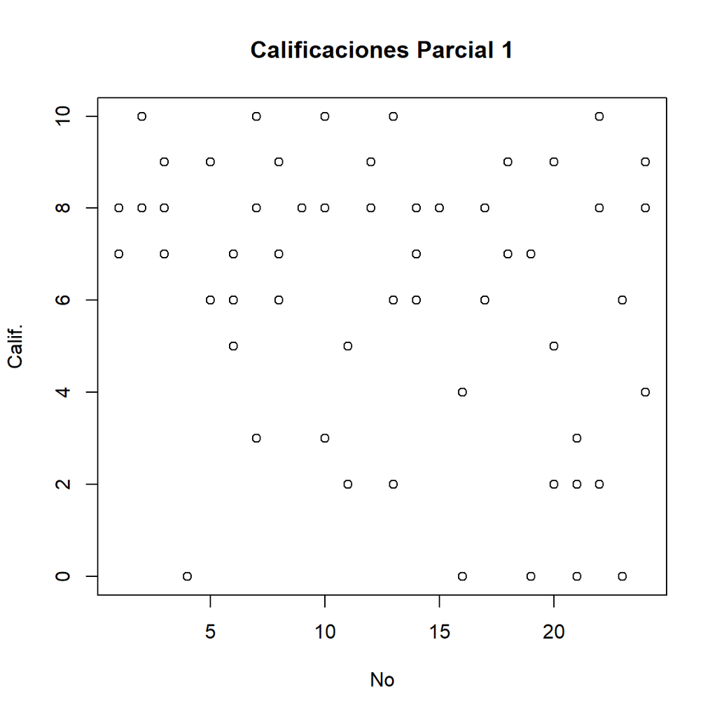

```r
datoscsv <- resultados_csv
plot(datoscsv$No, datoscsv$Calificacion, main = "Calificaciones Parcial 1", xlab = "No", ylab = "Calif.")
```

3.- Renombrar `Ev.` a `Parcial 3` (mostrar el `data.frame` resultante).

```r
colnames(resultados_csv)[colnames(resultados_csv) == "Examen"] <- "Parcial"
print(resultados_csv)
```

```
   No Matricula                              Nombre Calif.  Parcial
1   1 150300135          ALEJO ALEJANDRO / MIJARES       7 Parcial1
2   2 150300161          CAN BACAB / HECTOR ARTURO       9 Parcial1
3   3 150300087         CAN BACAB / SERGIO ANTONIO       8 Parcial1
4   4 140300086    CERVANTES VILLEGAS / ALAN JAIME       0 Parcial1
5   5 150300109       CONSTANTINO ISNEROS / MOISES       8 Parcial1
6   6 150300170             CORONA MERCADO / JESUS       6 Parcial1
7   7 150300508     DE LA CRUZ MARTÍNEZ / MAURICIO       7 Parcial1
8   8 150300107     GALINDO ARROYO / FERNANDO IVAN       7 Parcial1
9   9 150300511            GARCIA VAZQUEZ / BRANDO       8 Parcial1
10 10 150300123               GIL GUZMAN / GIOVANY       7 Parcial1
11 11 150300093     HERNANDEZ GUZMAN / JULIO CESAR       4 Parcial1
12 12 150300092 HERNÁNDEZ VALENCIA / ESTEBAN RAMÓN       9 Parcial1
   Calificacion
1             8
2            10
3             7
4             0
5             9
6             7
7             8
8             7
9             8
10            8
11            5
12            8
 [ reached 'max' / getOption("max.print") -- omitted 60 rows ]
```

4.- Graficar `No` contra `Calif.`, `Calificacion`.

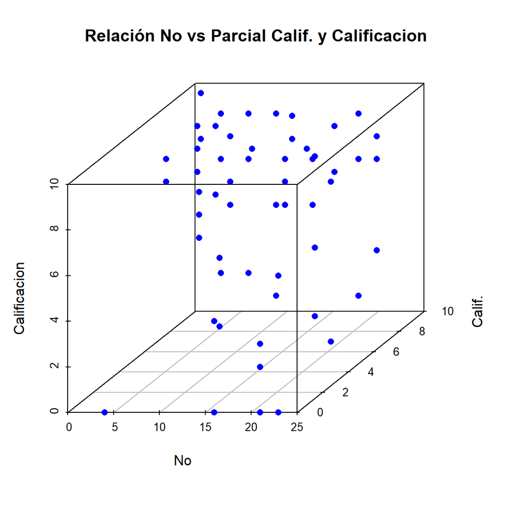

```r
library(scatterplot3d)
scatterplot3d(resultados_csv$No, resultados_csv$Calif., resultados_csv$Calificacion,
              main = "Relación No vs Parcial Calif. y Calificacion",
              xlab = "No", ylab = "Calif.", zlab = "Calificacion",
              color = "blue", pch = 16)
```

5.- ¿Cuál es la media de las calificaciones finales? ¿Quién obtuvo la calificación más baja? ¿Quién obtuvo el mejor promedio? (anexar el código que lo calcula).

```r
#Calificación más baja
calfmedia_csv <- mean(resultados_csv$Calificacion, na.rm = TRUE)
calfbaja_csv <- min(resultados_csv$Calificacion)
calfmejor_csv <- max(resultados_csv$Calificacion)

#Imprimir resultados
print(paste("Media Calificacion:", calfmedia_csv))
```

```
[1] "Media Calificacion: 6.05555555555556"
```

```r
print(paste("Calificación más baja:", calfbaja_csv))
```

```
[1] "Calificación más baja: 0"
```

```r
print(paste("La mejor Calificiación:", calfmejor_csv))
```

```
[1] "La mejor Calificiación: 10"
```

6.- Cree una nueva columna llamada `promedio` (esto lo puede hacer con `mutate` del paquete `dplyr`) y compárela con la columna `Calificacion` (¿Qué se puede observar?).

```r
resultados_csv <- resultados_csv %>%
  mutate(promedio = mean(Calificacion, na.rm = TRUE))
print(resultados_csv)
```

```
   No Matricula                           Nombre Calif.  Parcial Calificacion
1   1 150300135       ALEJO ALEJANDRO / MIJARES       7 Parcial1            8
2   2 150300161       CAN BACAB / HECTOR ARTURO       9 Parcial1           10
3   3 150300087      CAN BACAB / SERGIO ANTONIO       8 Parcial1            7
4   4 140300086 CERVANTES VILLEGAS / ALAN JAIME       0 Parcial1            0
5   5 150300109    CONSTANTINO ISNEROS / MOISES       8 Parcial1            9
6   6 150300170          CORONA MERCADO / JESUS       6 Parcial1            7
7   7 150300508  DE LA CRUZ MARTÍNEZ / MAURICIO       7 Parcial1            8
8   8 150300107  GALINDO ARROYO / FERNANDO IVAN       7 Parcial1            7
9   9 150300511         GARCIA VAZQUEZ / BRANDO       8 Parcial1            8
10 10 150300123            GIL GUZMAN / GIOVANY       7 Parcial1            8
   promedio
1  6.055556
2  6.055556
3  6.055556
4  6.055556
5  6.055556
6  6.055556
7  6.055556
8  6.055556
9  6.055556
10 6.055556
 [ reached 'max' / getOption("max.print") -- omitted 62 rows ]
```